# Customer Segmentation Analysis Part 1

```python
# Import the appropriate Libraries
import pandas as pd # for dataframes
import matplotlib.pyplot as plt # for plotting graphs
import seaborn as sns # for plotting graphs
import datetime as dt
import numpy as np
```

```python
# Check encoding in the dataset because if you load the dataset without encoding an error will occur

# pip install chardet
# import the chardet library and use the detect method to find the type of encoding

import chardet

# 'rb' means read in the file as binary
# with open("Sales_data.csv", 'rb') as file:
#     print(chardet.detect(file.read()))
```

## Use encoding results in code provided below v

```python
# Load the dataset
data = pd.read_csv('Sales_data.csv', encoding='ISO-8859-1')
data
```

|  | InvoiceNo | StockCode | Description | Quantity | InvoiceDate | UnitPrice | CustomerID | Country |
| --- | --- | --- | --- | --- | --- | --- | --- | --- |
| 0 | 536365 | 85123A | WHITE HANGING HEART T-LIGHT HOLDER | 6 | 12/1/2010 8:26 | 2.55 | 17850.0 | United Kingdom |
| 1 | 536365 | 71053 | WHITE METAL LANTERN | 6 | 12/1/2010 8:26 | 3.39 | 17850.0 | United Kingdom |
| 2 | 536365 | 84406B | CREAM CUPID HEARTS COAT HANGER | 8 | 12/1/2010 8:26 | 2.75 | 17850.0 | United Kingdom |
| 3 | 536365 | 84029G | KNITTED UNION FLAG HOT WATER BOTTLE | 6 | 12/1/2010 8:26 | 3.39 | 17850.0 | United Kingdom |
| 4 | 536365 | 84029E | RED WOOLLY HOTTIE WHITE HEART. | 6 | 12/1/2010 8:26 | 3.39 | 17850.0 | United Kingdom |
| ... | ... | ... | ... | ... | ... | ... | ... | ... |
| 541904 | 581587 | 22613 | PACK OF 20 SPACEBOY NAPKINS | 12 | 12/9/2011 12:50 | 0.85 | 12680.0 | France |
| 541905 | 581587 | 22899 | CHILDREN'S APRON DOLLY GIRL | 6 | 12/9/2011 12:50 | 2.10 | 12680.0 | France |
| 541906 | 581587 | 23254 | CHILDRENS CUTLERY DOLLY GIRL | 4 | 12/9/2011 12:50 | 4.15 | 12680.0 | France |
| 541907 | 581587 | 23255 | CHILDRENS CUTLERY CIRCUS PARADE | 4 | 12/9/2011 12:50 | 4.15 | 12680.0 | France |
| 541908 | 581587 | 22138 | BAKING SET 9 PIECE RETROSPOT | 3 | 12/9/2011 12:50 | 4.95 | 12680.0 | France |

541909 rows × 8 columns

## Data Exploration

```python
data.info()
```

```
<class 'pandas.core.frame.DataFrame'>
RangeIndex: 541909 entries, 0 to 541908
Data columns (total 8 columns):
 #   Column       Non-Null Count   Dtype
---  ------       --------------   -----
 0   InvoiceNo    541909 non-null  object
 1   StockCode    541909 non-null  object
 2   Description  540455 non-null  object
 3   Quantity     541909 non-null  int64
 4   InvoiceDate  541909 non-null  object
 5   UnitPrice    541909 non-null  float64
 6   CustomerID   406829 non-null  float64
 7   Country      541909 non-null  object
dtypes: float64(2), int64(1), object(5)
memory usage: 33.1+ MB
```

```python
data.shape
```

```
(541909, 8)
```

```python
data.Description.value_counts()
```

```
WHITE HANGING HEART T-LIGHT HOLDER     2369
REGENCY CAKESTAND 3 TIER               2200
JUMBO BAG RED RETROSPOT                2159
PARTY BUNTING                          1727
LUNCH BAG RED RETROSPOT                1638
                                       ...
Missing                                   1
historic computer difference?....se       1
DUSTY PINK CHRISTMAS TREE 30CM            1
WRAP BLUE RUSSIAN FOLKART                 1
PINK BERTIE MOBILE PHONE CHARM            1
Name: Description, Length: 4223, dtype: int64
```

## Data Preprocessing

```python
# Take all the rows where customer ID not equal to blank
data= data[pd.notnull(data['CustomerID'])]
```

```python
data.shape
```

```
(406829, 8)
```

```python
data.info()
```

```
<class 'pandas.core.frame.DataFrame'>
Int64Index: 406829 entries, 0 to 541908
Data columns (total 8 columns):
 #   Column       Non-Null Count   Dtype
---  ------       --------------   -----
 0   InvoiceNo    406829 non-null  object
 1   StockCode    406829 non-null  object
 2   Description  406829 non-null  object
 3   Quantity     406829 non-null  int64
 4   InvoiceDate  406829 non-null  object
 5   UnitPrice    406829 non-null  float64
 6   CustomerID   406829 non-null  float64
 7   Country      406829 non-null  object
dtypes: float64(2), int64(1), object(5)
memory usage: 27.9+ MB
```

```python
data.head()
```

|  | InvoiceNo | StockCode | Description | Quantity | InvoiceDate | UnitPrice | CustomerID | Country |
| --- | --- | --- | --- | --- | --- | --- | --- | --- |
| 0 | 536365 | 85123A | WHITE HANGING HEART T-LIGHT HOLDER | 6 | 12/1/2010 8:26 | 2.55 | 17850.0 | United Kingdom |
| 1 | 536365 | 71053 | WHITE METAL LANTERN | 6 | 12/1/2010 8:26 | 3.39 | 17850.0 | United Kingdom |
| 2 | 536365 | 84406B | CREAM CUPID HEARTS COAT HANGER | 8 | 12/1/2010 8:26 | 2.75 | 17850.0 | United Kingdom |
| 3 | 536365 | 84029G | KNITTED UNION FLAG HOT WATER BOTTLE | 6 | 12/1/2010 8:26 | 3.39 | 17850.0 | United Kingdom |
| 4 | 536365 | 84029E | RED WOOLLY HOTTIE WHITE HEART. | 6 | 12/1/2010 8:26 | 3.39 | 17850.0 | United Kingdom |

```python
# Removing duplicates
filtered_data=data[['Country','CustomerID']].drop_duplicates()
```

```python
filtered_data.shape
```

```
(4380, 2)
```

```python
filtered_data.head()
```

|  | Country | CustomerID |
| --- | --- | --- |
| 0 | United Kingdom | 17850.0 |
| 9 | United Kingdom | 13047.0 |
| 26 | France | 12583.0 |
| 46 | United Kingdom | 13748.0 |
| 65 | United Kingdom | 15100.0 |

```python
filtered_data.info()
```

```
<class 'pandas.core.frame.DataFrame'>
Int64Index: 4380 entries, 0 to 541768
Data columns (total 2 columns):
 #   Column      Non-Null Count  Dtype
---  ------      --------------  -----
 0   Country     4380 non-null   object
 1   CustomerID  4380 non-null   float64
dtypes: float64(1), object(1)
memory usage: 102.7+ KB
```

## Data Insights

```python
# Check the country wise distribution
data.Country.value_counts()
```

```
United Kingdom          361878
Germany                   9495
France                    8491
EIRE                      7485
Spain                     2533
Netherlands               2371
Belgium                   2069
Switzerland               1877
Portugal                  1480
Australia                 1259
Norway                    1086
Italy                      803
Channel Islands            758
Finland                    695
Cyprus                     622
Sweden                     462
Austria                    401
Denmark                    389
Japan                      358
Poland                     341
USA                        291
Israel                     250
Unspecified                244
Singapore                  229
Iceland                    182
Canada                     151
Greece                     146
Malta                      127
United Arab Emirates        68
European Community          61
RSA                         58
Lebanon                     45
Lithuania                   35
Brazil                      32
Czech Republic              30
Bahrain                     17
Saudi Arabia                10
Name: Country, dtype: int64
```

```python
filtered_data.Country.value_counts()[:10]
```

```
United Kingdom    3950
Germany             95
France              87
Spain               31
Belgium             25
Switzerland         21
Portugal            19
Italy               15
Finland             12
Austria             11
Name: Country, dtype: int64
```

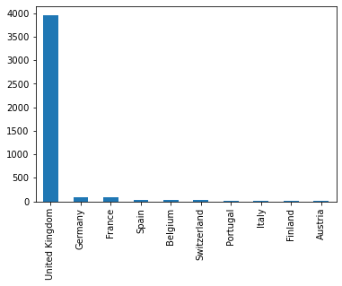

```python
# Plot the data
filtered_data.Country.value_counts()[:10].plot(kind='bar')
```

## Q. What do you observe?

- From the above bar graph, we can see that most of the customers are from united kingdom which is far more than other countries.

```python
## Filter data by the top most country
uk_data=data[data.Country=='United Kingdom']
```

```python
uk_data.describe()
```

|  | Quantity | UnitPrice | CustomerID |
| --- | --- | --- | --- |
| count | 361878.000000 | 361878.000000 | 361878.000000 |
| mean | 11.077029 | 3.256007 | 15547.871368 |
| std | 263.129266 | 70.654731 | 1594.402590 |
| min | -80995.000000 | 0.000000 | 12346.000000 |
| 25% | 2.000000 | 1.250000 | 14194.000000 |
| 50% | 4.000000 | 1.950000 | 15514.000000 |
| 75% | 12.000000 | 3.750000 | 16931.000000 |
| max | 80995.000000 | 38970.000000 | 18287.000000 |

## Q. What do you observe? Which column needs special attention?

From the above table quantity and Unitprice needs special attention

- In the quantity column,std is 263.12 but max value is 80995.00 which seems to be unusal and minimum quantity is -80995.quantity can not be negative.so, it may be a typing error.
- In the UnitPrice column, std is 70 but max value is 38970 which seems to be unusual.

```python
uk_data = uk_data[(uk_data['Quantity'] > 0)]
```

```python
uk_data.info()
```

```
<class 'pandas.core.frame.DataFrame'>
Int64Index: 354345 entries, 0 to 541893
Data columns (total 8 columns):
 #   Column       Non-Null Count   Dtype
---  ------       --------------   -----
 0   InvoiceNo    354345 non-null  object
 1   StockCode    354345 non-null  object
 2   Description  354345 non-null  object
 3   Quantity     354345 non-null  int64
 4   InvoiceDate  354345 non-null  object
 5   UnitPrice    354345 non-null  float64
 6   CustomerID   354345 non-null  float64
 7   Country      354345 non-null  object
dtypes: float64(2), int64(1), object(5)
memory usage: 24.3+ MB
```

```python
uk_data.head()
```

|  | InvoiceNo | StockCode | Description | Quantity | InvoiceDate | UnitPrice | CustomerID | Country |
| --- | --- | --- | --- | --- | --- | --- | --- | --- |
| 0 | 536365 | 85123A | WHITE HANGING HEART T-LIGHT HOLDER | 6 | 12/1/2010 8:26 | 2.55 | 17850.0 | United Kingdom |
| 1 | 536365 | 71053 | WHITE METAL LANTERN | 6 | 12/1/2010 8:26 | 3.39 | 17850.0 | United Kingdom |
| 2 | 536365 | 84406B | CREAM CUPID HEARTS COAT HANGER | 8 | 12/1/2010 8:26 | 2.75 | 17850.0 | United Kingdom |
| 3 | 536365 | 84029G | KNITTED UNION FLAG HOT WATER BOTTLE | 6 | 12/1/2010 8:26 | 3.39 | 17850.0 | United Kingdom |
| 4 | 536365 | 84029E | RED WOOLLY HOTTIE WHITE HEART. | 6 | 12/1/2010 8:26 | 3.39 | 17850.0 | United Kingdom |

```python
# Filter the required columns only
uk_data=uk_data[['CustomerID','InvoiceDate','InvoiceNo','Quantity','UnitPrice']]
```

```python
# Calculate Total Price
uk_data['TotalPrice'] = uk_data['Quantity'] * uk_data['UnitPrice']
```

## Time frame of data

```python
# Check Min and Max dates
print(uk_data['InvoiceDate'].min())
print(uk_data['InvoiceDate'].max())
```

```
1/10/2011 10:32
9/9/2011 9:52
```

### Q. Comment on the above results.

InvoiceDate is not in proper format. If we look at the Invoicedate column,date starts from 01-12-2010 but here min value is showing 01-10-2011 which is wrong. so, it needs to be converted to datetime format.

## Perform RFM Analysis

- For Recency, Calculate the number of days between present date and date of last purchase for each customer.
- Frequency, Calculate the number of orders for each customer.
- For Monetary, Calculate sum of purchase price for each customer

```python
# Store a date as a reference point for recency calculations
PRESENT = dt.datetime(2011, 12, 10)

# Convert date to datetime format
uk_data['InvoiceDate'] = pd.to_datetime(uk_data['InvoiceDate'])
```

```python
uk_data['InvoiceDate'].head()
```

```
0   2010-12-01 08:26:00
1   2010-12-01 08:26:00
2   2010-12-01 08:26:00
3   2010-12-01 08:26:00
4   2010-12-01 08:26:00
Name: InvoiceDate, dtype: datetime64[ns]
```

```python
uk_data['InvoiceNo'].value_counts().head()
```

```
576339    542
579196    533
580727    529
578270    442
573576    435
Name: InvoiceNo, dtype: int64
```

## Q. Comment on the above results

```python
orders = uk_data.groupby(['InvoiceNo', 'InvoiceDate', 'CustomerID']).agg({'TotalPrice': lambda x: x.sum()}).reset_index()
orders.head()
```

|  | InvoiceNo | InvoiceDate | CustomerID | TotalPrice |
| --- | --- | --- | --- | --- |
| 0 | 536365 | 2010-12-01 08:26:00 | 17850.0 | 139.12 |
| 1 | 536366 | 2010-12-01 08:28:00 | 17850.0 | 22.20 |
| 2 | 536367 | 2010-12-01 08:34:00 | 13047.0 | 278.73 |
| 3 | 536368 | 2010-12-01 08:34:00 | 13047.0 | 70.05 |
| 4 | 536369 | 2010-12-01 08:35:00 | 13047.0 | 17.85 |

```python
rfm= uk_data.groupby('CustomerID').agg({'InvoiceDate': lambda date: (PRESENT - date.max()).days,
                                        'InvoiceNo': lambda num: len(num),
                                        'TotalPrice': lambda price: price.sum()})
```

```python
rfm
```

| CustomerID | InvoiceDate | InvoiceNo | TotalPrice |
| --- | --- | --- | --- |
| 12346.0 | 325 | 1 | 77183.60 |
| 12747.0 | 2 | 103 | 4196.01 |
| 12748.0 | 0 | 4596 | 33719.73 |
| 12749.0 | 3 | 199 | 4090.88 |
| 12820.0 | 3 | 59 | 942.34 |
| ... | ... | ... | ... |
| 18280.0 | 277 | 10 | 180.60 |
| 18281.0 | 180 | 7 | 80.82 |
| 18282.0 | 7 | 12 | 178.05 |
| 18283.0 | 3 | 756 | 2094.88 |
| 18287.0 | 42 | 70 | 1837.28 |

3921 rows × 3 columns

```python
# Rename the columns
rfm.columns=['monetary','frequency','recency']
```

```python
rfm['recency'] = rfm['recency'].astype(int)
```

```python
rfm['monetary'] = rfm['monetary'].astype(int)
```

```python
rfm.head()
```

| CustomerID | monetary | frequency | recency |
| --- | --- | --- | --- |
| 12346.0 | 325 | 1 | 77183 |
| 12747.0 | 2 | 103 | 4196 |
| 12748.0 | 0 | 4596 | 33719 |
| 12749.0 | 3 | 199 | 4090 |
| 12820.0 | 3 | 59 | 942 |

## Q. What is wrong with this table ?

Names have not been identified correctly. we need to swap the recency and monetary

```python
rfm.columns=['recency','frequency','monetary']
```

## Create Visuals

- Histogram for Recency Data
- Histogram for Frequency Data
- Histogram for Monetary Data

```
array([[<AxesSubplot:title={'center':'recency'}>]], dtype=object)
```

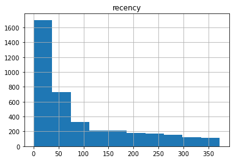

```python
# Histogram for Recency Data (UK)
rfm.hist(column='recency')
```

## Q. What does this above chart tell ?

More than 1600 customers are returning before 50 days.

```
array([[<AxesSubplot:title={'center':'frequency'}>]], dtype=object)
```

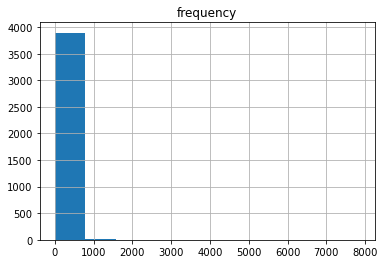

```python
# Histogram for Frequency Data (UK)

rfm.hist(column='frequency')
```

```
array([[<AxesSubplot:title={'center':'monetary'}>]], dtype=object)
```

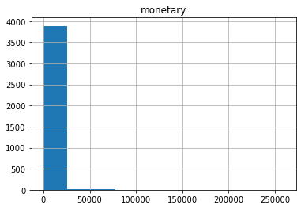

```python
# Histogram for Monetary Data (UK)
rfm.hist(column='monetary')
```

### Q. What does this above chart tell ?

From the chart we can see that there are more than 3800 customers whose monetary is below 25000.

# Calcualte the RFM Score

```python
# Use quintiles to to make 5 equal parts based on the available values. Each quintiles contains 20% of the population.
quintiles = rfm[['recency', 'frequency', 'monetary']].quantile([.2, .4, .6, .8]).to_dict()
quintiles
```

```
{'recency': {0.2: 12.0, 0.4: 32.0, 0.6: 71.0, 0.8: 178.0},
 'frequency': {0.2: 13.0, 0.4: 29.0, 0.6: 58.0, 0.8: 120.0},
 'monetary': {0.2: 241.0, 0.4: 465.0, 0.6: 897.0, 0.8: 1957.0}}
```

```python
# Define functions to assign ranks from 1 to 5.
# A lower Recency value is better and higher Frequency and Monetary values are better.
# We will have to write two separate functions
def r_score(x):
    if x <= quintiles['recency'][.2]:
        return 5
    elif x <= quintiles['recency'][.4]:
        return 4
    elif x <= quintiles['recency'][.6]:
        return 3
    elif x <= quintiles['recency'][.8]:
        return 2
    else:
        return 1

def fm_score(x, c):
    if x <= quintiles[c][.2]:
        return 1
    elif x <= quintiles[c][.4]:
        return 2
    elif x <= quintiles[c][.6]:
        return 3
    elif x <= quintiles[c][.8]:
        return 4
    else:
        return 5
```

```python
# Calculate RFM score for each customer

rfm['R'] = rfm['recency'].apply(lambda x: r_score(x))
rfm['F'] = rfm['frequency'].apply(lambda x: fm_score(x, 'frequency'))
rfm['M'] = rfm['monetary'].apply(lambda x: fm_score(x, 'monetary'))
```

```python
# Combine the scores
rfm['RFM Score'] = rfm['R'].map(str) + rfm['F'].map(str) + rfm['M'].map(str)
rfm.head()
```

| CustomerID | recency | frequency | monetary | R | F | M | RFM Score |
| --- | --- | --- | --- | --- | --- | --- | --- |
| 12346.0 | 325 | 1 | 77183 | 1 | 1 | 5 | 115 |
| 12747.0 | 2 | 103 | 4196 | 5 | 4 | 5 | 545 |
| 12748.0 | 0 | 4596 | 33719 | 5 | 5 | 5 | 555 |
| 12749.0 | 3 | 199 | 4090 | 5 | 5 | 5 | 555 |
| 12820.0 | 3 | 59 | 942 | 5 | 4 | 4 | 544 |

```python
# Create the customer segments based on your knowledge.
# Create 6 segments based on R and F scores

segments = {
    '[1-2][1-4]': 'at risk',
    '[1-2]5': 'can\'t loose',
    '3[1-3]': 'needs attention',
    '[3-4][4-5]': 'loyal customers',
    '[4-5]1': 'new customers',
    '[4-5][2-5]': 'champions'

}

rfm['Segment'] = rfm['R'].map(str) + rfm['F'].map(str)
rfm['Segment'] = rfm['Segment'].replace(segments, regex=True)
rfm.head()
```

| CustomerID | recency | frequency | monetary | R | F | M | RFM Score | Segment |
| --- | --- | --- | --- | --- | --- | --- | --- | --- |
| 12346.0 | 325 | 1 | 77183 | 1 | 1 | 5 | 115 | at risk |
| 12747.0 | 2 | 103 | 4196 | 5 | 4 | 5 | 545 | champions |
| 12748.0 | 0 | 4596 | 33719 | 5 | 5 | 5 | 555 | champions |
| 12749.0 | 3 | 199 | 4090 | 5 | 5 | 5 | 555 | champions |
| 12820.0 | 3 | 59 | 942 | 5 | 4 | 4 | 544 | champions |

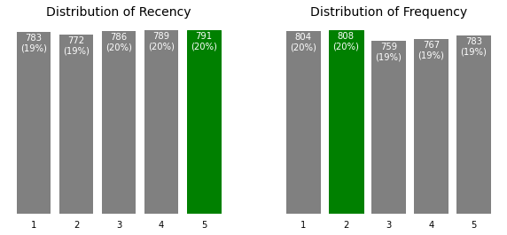

```python
# plot the distribution of customers over R and F
fig, axes = plt.subplots(nrows=1, ncols=2, figsize=(10, 4))

for i, p in enumerate(['R', 'F']):
    parameters = {'R':'Recency', 'F':'Frequency'}
    y = rfm[p].value_counts().sort_index()
    x = y.index
    ax = axes[i]
    bars = ax.bar(x, y, color='gray')
    ax.set_frame_on(False)
    ax.tick_params(left=False, labelleft=False, bottom=False)
    ax.set_title('Distribution of {}'.format(parameters[p]),
                fontsize=14)
    for bar in bars:
        value = bar.get_height()
        if value == y.max():
            bar.set_color('green')
        ax.text(bar.get_x() + bar.get_width() / 2,
                value - 5,
                '{}\n({}%)'.format(int(value), int(value * 100 / y.sum())),
               ha='center',
               va='top',
               color='w')

plt.show()
```

### Q. What do you observe with the above charts

```python
# count the number of customers in each segment
segments_counts = rfm['Segment'].value_counts().sort_values(ascending=True)

segments_counts
```

```
can't loose          74
new customers       146
needs attention     486
loyal customers     722
champions          1012
at risk            1481
Name: Segment, dtype: int64
```

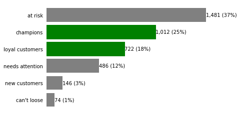

```python
# Distribution of Segments
fig, ax = plt.subplots()

bars = ax.barh(range(len(segments_counts)),
              segments_counts,
              color='gray')
ax.set_frame_on(False)
ax.tick_params(left=False,
               bottom=False,
               labelbottom=False)
ax.set_yticks(range(len(segments_counts)))
ax.set_yticklabels(segments_counts.index)

for i, bar in enumerate(bars):
        value = bar.get_width()
        if segments_counts.index[i] in ['champions', 'loyal customers']:
            bar.set_color('green')
        ax.text(value,
                bar.get_y() + bar.get_height()/2,
                '{:,} ({:}%)'.format(int(value),
                                   int(value*100/segments_counts.sum())),
                va='center',
                ha='left'
               )

plt.show()
```

### Q. Who are the best customers?

Champions, loyal customers are best customers

```python
rfm[rfm['RFM Score']=='555'].sort_values('monetary', ascending=False).head()
```

| CustomerID | recency | frequency | monetary | R | F | M | RFM Score | Segment |
| --- | --- | --- | --- | --- | --- | --- | --- | --- |
| 18102.0 | 0 | 431 | 259657 | 5 | 5 | 5 | 555 | champions |
| 17450.0 | 8 | 337 | 194550 | 5 | 5 | 5 | 555 | champions |
| 17511.0 | 2 | 963 | 91062 | 5 | 5 | 5 | 555 | champions |
| 16684.0 | 4 | 277 | 66653 | 5 | 5 | 5 | 555 | champions |
| 14096.0 | 4 | 5111 | 65164 | 5 | 5 | 5 | 555 | champions |

### Q. Which customers are likely to churn?

Customes, whose RFM Score is 111 is likely to churn

```python
#Customers who's recency value is low

rfm[rfm['R'] <= 1 ].sort_values('monetary', ascending=False).head()
```

| CustomerID | recency | frequency | monetary | R | F | M | RFM Score | Segment |
| --- | --- | --- | --- | --- | --- | --- | --- | --- |
| 12346.0 | 325 | 1 | 77183 | 1 | 1 | 5 | 115 | at risk |
| 15749.0 | 235 | 10 | 44534 | 1 | 1 | 5 | 115 | at risk |
| 15098.0 | 182 | 3 | 39916 | 1 | 1 | 5 | 115 | at risk |
| 13093.0 | 275 | 159 | 7832 | 1 | 5 | 5 | 155 | can't loose |
| 17850.0 | 372 | 297 | 5391 | 1 | 5 | 5 | 155 | can't loose |

### Q. Which customers we are going to loose?

Whose R score is less than or equal to 1.

```python
#Customers who's recency, frequency and monetary values are low

rfm[rfm['RFM Score']=='111'].sort_values('recency',ascending=False).head()
```

| CustomerID | recency | frequency | monetary | R | F | M | RFM Score | Segment |
| --- | --- | --- | --- | --- | --- | --- | --- | --- |
| 13747.0 | 373 | 1 | 79 | 1 | 1 | 1 | 111 | at risk |
| 14237.0 | 373 | 9 | 161 | 1 | 1 | 1 | 111 | at risk |
| 17643.0 | 373 | 8 | 101 | 1 | 1 | 1 | 111 | at risk |
| 15350.0 | 373 | 5 | 115 | 1 | 1 | 1 | 111 | at risk |
| 13011.0 | 372 | 3 | 50 | 1 | 1 | 1 | 111 | at risk |

### Q. Who are the loyal customers?

Customes who purchase products regular, whose F score is greater than or euqal to 3.

```python
#Customers with high frequency value

rfm[rfm['F'] >= 3 ].sort_values('monetary', ascending=False).head()
```

| CustomerID | recency | frequency | monetary | R | F | M | RFM Score | Segment |
| --- | --- | --- | --- | --- | --- | --- | --- | --- |
| 18102.0 | 0 | 431 | 259657 | 5 | 5 | 5 | 555 | champions |
| 17450.0 | 8 | 337 | 194550 | 5 | 5 | 5 | 555 | champions |
| 17511.0 | 2 | 963 | 91062 | 5 | 5 | 5 | 555 | champions |
| 16029.0 | 38 | 242 | 81024 | 3 | 5 | 5 | 355 | loyal customers |
| 16684.0 | 4 | 277 | 66653 | 5 | 5 | 5 | 555 | champions |

## Calculate RFM scores using 4 quintiles instead of 5 and answer all the questions again

```python
# Use quintiles to to make 4 equal parts based on the available values. Each quintiles contains 25% of the population.
quintiles = rfm[['recency', 'frequency', 'monetary']].quantile([.25, .5, .75]).to_dict()
quintiles
```

```
{'recency': {0.25: 17.0, 0.5: 50.0, 0.75: 142.0},
 'frequency': {0.25: 17.0, 0.5: 41.0, 0.75: 99.0},
 'monetary': {0.25: 300.0, 0.5: 651.0, 0.75: 1575.0}}
```

```python
# Define functions to assign ranks from 1 to 4.
# A lower Recency value is better and higher Frequency and Monetary values are better.
# We will have to write two separate functions
def r_score(x):
    if x <= quintiles['recency'][.25]:
        return 4
    elif x <= quintiles['recency'][.50]:
        return 3
    elif x <= quintiles['recency'][.75]:
        return 2
    else:
        return 1

def fm_score(x, c):
    if x <= quintiles[c][.25]:
        return 1
    elif x <= quintiles[c][.50]:
        return 2
    elif x <= quintiles[c][.75]:
        return 3
    else:
        return 4
```

```python
# Calculate RFM score for each customer

rfm['R'] = rfm['recency'].apply(lambda x: r_score(x))
rfm['F'] = rfm['frequency'].apply(lambda x: fm_score(x, 'frequency'))
rfm['M'] = rfm['monetary'].apply(lambda x: fm_score(x, 'monetary'))
```

```python
# Combine the scores
rfm['RFM Score'] = rfm['R'].map(str) + rfm['F'].map(str) + rfm['M'].map(str)
rfm.head()
```

| CustomerID | recency | frequency | monetary | R | F | M | RFM Score | Segment |
| --- | --- | --- | --- | --- | --- | --- | --- | --- |
| 12346.0 | 325 | 1 | 77183 | 1 | 1 | 4 | 114 | at risk |
| 12747.0 | 2 | 103 | 4196 | 4 | 4 | 4 | 444 | champions |
| 12748.0 | 0 | 4596 | 33719 | 4 | 4 | 4 | 444 | champions |
| 12749.0 | 3 | 199 | 4090 | 4 | 4 | 4 | 444 | champions |
| 12820.0 | 3 | 59 | 942 | 4 | 3 | 3 | 433 | champions |

```python
# Create the customer segments based on your knowledge.
# Create 4 segments based on R and F scores

segments = {
    '[1-2][1-3]': 'at risk',
    '[1-2][2-4]': 'needs attention',
    '[3-4][2-4]': 'loyal customers',
    '[1-4][1]': 'new customers'
}

rfm['Segment'] = rfm['R'].map(str) + rfm['F'].map(str)
rfm['Segment'] = rfm['Segment'].replace(segments, regex=True)
rfm.head()
```

| CustomerID | recency | frequency | monetary | R | F | M | RFM Score | Segment |
| --- | --- | --- | --- | --- | --- | --- | --- | --- |
| 12346.0 | 325 | 1 | 77183 | 1 | 1 | 4 | 114 | at risk |
| 12747.0 | 2 | 103 | 4196 | 4 | 4 | 4 | 444 | loyal customers |
| 12748.0 | 0 | 4596 | 33719 | 4 | 4 | 4 | 444 | loyal customers |
| 12749.0 | 3 | 199 | 4090 | 4 | 4 | 4 | 444 | loyal customers |
| 12820.0 | 3 | 59 | 942 | 4 | 3 | 3 | 433 | loyal customers |

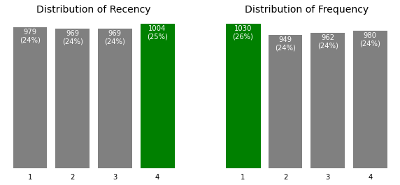

```python
# plot the distribution of customers over R and F
fig, axes = plt.subplots(nrows=1, ncols=2, figsize=(10, 4))

for i, p in enumerate(['R', 'F']):
    parameters = {'R':'Recency', 'F':'Frequency'}
    y = rfm[p].value_counts().sort_index()
    x = y.index
    ax = axes[i]
    bars = ax.bar(x, y, color='gray')
    ax.set_frame_on(False)
    ax.tick_params(left=False, labelleft=False, bottom=False)
    ax.set_title('Distribution of {}'.format(parameters[p]),
                fontsize=14)
    for bar in bars:
        value = bar.get_height()
        if value == y.max():
            bar.set_color('green')
        ax.text(bar.get_x() + bar.get_width() / 2,
                value - 5,
                '{}\n({}%)'.format(int(value), int(value * 100 / y.sum())),
               ha='center',
               va='top',
               color='w')

plt.show()
```

### What do you observe with the above charts?

```python
# count the number of customers in each segment
segments_counts = rfm['Segment'].value_counts().sort_values(ascending=True)

segments_counts
```

```
needs attention     186
new customers       264
loyal customers    1709
at risk            1762
Name: Segment, dtype: int64
```

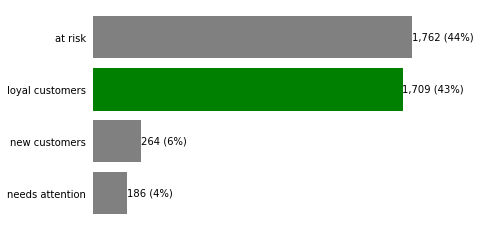

```python
# Distribution of Segments
fig, ax = plt.subplots()

bars = ax.barh(range(len(segments_counts)),
              segments_counts,
              color='gray')
ax.set_frame_on(False)
ax.tick_params(left=False,
               bottom=False,
               labelbottom=False)
ax.set_yticks(range(len(segments_counts)))
ax.set_yticklabels(segments_counts.index)

for i, bar in enumerate(bars):
        value = bar.get_width()
        if segments_counts.index[i] in ['champions', 'loyal customers']:
            bar.set_color('green')
        ax.text(value,
                bar.get_y() + bar.get_height()/2,
                '{:,} ({:}%)'.format(int(value),
                                   int(value*100/segments_counts.sum())),
                va='center',
                ha='left'
               )

plt.show()
```

### Comment on the above chart

44% customers are at risk, that means comapny may lost 1762 customers. 6% customer are new, there are 43% customer who will be stayed with company.

### Who are the best customers?

```python
rfm[rfm['RFM Score']=='444'].sort_values('monetary', ascending=False).head()
```

| CustomerID | recency | frequency | monetary | R | F | M | RFM Score | Segment |
| --- | --- | --- | --- | --- | --- | --- | --- | --- |
| 18102.0 | 0 | 431 | 259657 | 4 | 4 | 4 | 444 | loyal customers |
| 17450.0 | 8 | 337 | 194550 | 4 | 4 | 4 | 444 | loyal customers |
| 17511.0 | 2 | 963 | 91062 | 4 | 4 | 4 | 444 | loyal customers |
| 16684.0 | 4 | 277 | 66653 | 4 | 4 | 4 | 444 | loyal customers |
| 14096.0 | 4 | 5111 | 65164 | 4 | 4 | 4 | 444 | loyal customers |

### Which customers are likely to churn?

Customers whose R score is less than or equal to 1

```python
rfm[rfm['R'] <= 1 ].sort_values('monetary', ascending=False).head()
```

| CustomerID | recency | frequency | monetary | R | F | M | RFM Score | Segment |
| --- | --- | --- | --- | --- | --- | --- | --- | --- |
| 12346.0 | 325 | 1 | 77183 | 1 | 1 | 4 | 114 | at risk |
| 15749.0 | 235 | 10 | 44534 | 1 | 1 | 4 | 114 | at risk |
| 15098.0 | 182 | 3 | 39916 | 1 | 1 | 4 | 114 | at risk |
| 13093.0 | 275 | 159 | 7832 | 1 | 4 | 4 | 144 | needs attention |
| 12980.0 | 157 | 20 | 7374 | 1 | 2 | 4 | 124 | at risk |

# which customers we are going to loose?

Customers whose score is 111.

```python
rfm[rfm['RFM Score']=='111'].sort_values('recency',ascending=False).head()
```

| CustomerID | recency | frequency | monetary | R | F | M | RFM Score | Segment |
| --- | --- | --- | --- | --- | --- | --- | --- | --- |
| 13065.0 | 373 | 14 | 205 | 1 | 1 | 1 | 111 | at risk |
| 16583.0 | 373 | 14 | 233 | 1 | 1 | 1 | 111 | at risk |
| 16048.0 | 373 | 8 | 256 | 1 | 1 | 1 | 111 | at risk |
| 13747.0 | 373 | 1 | 79 | 1 | 1 | 1 | 111 | at risk |
| 17643.0 | 373 | 8 | 101 | 1 | 1 | 1 | 111 | at risk |

### Q. Who are the loyal customers?

Customers whose frequency score is higher or equal to 3

```python
rfm[rfm['F'] >= 3 ].sort_values('monetary', ascending=False).head()
```

| CustomerID | recency | frequency | monetary | R | F | M | RFM Score | Segment |
| --- | --- | --- | --- | --- | --- | --- | --- | --- |
| 18102.0 | 0 | 431 | 259657 | 4 | 4 | 4 | 444 | loyal customers |
| 17450.0 | 8 | 337 | 194550 | 4 | 4 | 4 | 444 | loyal customers |
| 17511.0 | 2 | 963 | 91062 | 4 | 4 | 4 | 444 | loyal customers |
| 16029.0 | 38 | 242 | 81024 | 3 | 4 | 4 | 344 | loyal customers |
| 16684.0 | 4 | 277 | 66653 | 4 | 4 | 4 | 444 | loyal customers |